# Loan Data from Prosper

## What is the structure of your dataset?

> In this notebook The dataset contains 113,937 loans with 81 features for each loan. but we select only 11 attributes in order to understand what coefficients affect a loan's outcome status.

> The column header descriptions are as follows:
> - **ListingCategory**  
>   The category of the listing that the borrower selected when posting their listing: 0 - Not Available, 1 - Debt Consolidation, 2 - Home Improvement, 3 - Business, 4 - Personal Loan, 5 - Student Use, 6 - Auto, 7- Other, 8 - Baby&Adoption, 9 - Boat, 10 - Cosmetic Procedure, 11 - Engagement Ring, 12 - Green Loans, 13 - Household Expenses, 14 - Large Purchases, 15 - Medical/Dental, 16 - Motorcycle, 17 - RV, 18 - Taxes, 19 - Vacation, 20 - Wedding Loans.
> - **EmploymentStatusDuration**  
>   The length in months of the employment status at the time the listing was created.
> - **EmploymentStatus**  
>   The employment status of the borrower at the time they posted the listing.
> - **ProsperScore**  
>   A custom risk score built using historical Prosper data. The score ranges from 1-10, with 10 being the best, or lowest risk score. Applicable for loans originated after July 2009.
> - **CurrentCreditLines**  
>   Number of current credit lines at the time the credit profile was pulled.
> - **IsBorrowerHomeowner**  
>   A Borrower will be classified as a homowner if they have a mortgage on their credit profile or provide documentation confirming they are a homeowner.
> - **OpenRevolvingAccounts**  
>   Number of open revolving accounts at the time the credit profile was pulled.
> - **CurrentCreditLines**  
>   Number of current credit lines at the time the credit profile was pulled.
> - **IncomeVerifiable**  
>   The borrower indicated they have the required documentation to support their income.
> - **DebtToIncomeRatio**  
>   The debt to income ratio of the borrower at the time the credit profile was pulled. This value is Null if the debt to income ratio is not available. This value is capped at 10.01 (any debt to income ratio larger than 1000% will be returned as 1001%).
> - **LoanOriginalAmount**  
>   The origination amount of the loan.
> - **LoanStatus**  
>   The current status of the loan.

## What is/are the main feature(s) of interest in your dataset?

> The main feature in my consideration is loan's outcome status and what factors affect it. The loan may be Cancelled, Chargedoff(a declaration by a creditor. This occurs when a consumer becomes severely delinquent on a debt), Completed, Current, Defaulted, FinalPaymentInProgress, PastDue: Past due refers to a payment that has not been made by its cutoff time at the end of its due date.

## What features in the dataset do you think will help support your investigation into your feature(s) of interest?

> some borrowers' attributes that indicate their behavior will be utilized heavily, and figuring out why one loans percentage results Past Due, Defaulted or charged off.

# Univariate Exploration

In this section, I will investigate distributions of individual variables, and find out the relationships between variables.

```python
# Setting colors to the variable no_color
no_color = sns.color_palette()[0]
```

### LoanStatus

```python
#  creat table to show counts and percentages togegher for the load status
loanStatus = selected_df['LoanStatus'].value_counts()
loanStatus_per = selected_df['LoanStatus'].value_counts(normalize=True) * 100

loanStatus_overall = pd.concat([loanStatus, loanStatus_per], axis=1).set_axis(['loan status', 'percentage'], axis=1, inplace=False)

print(loanStatus_overall)
```

```
                        loan status  percentage
Current                       56570   49.870849
Completed                     37780   33.306004
Chargedoff                    11919   10.507524
Defaulted                      4887    4.308270
Past Due (1-15 days)            806    0.710552
Past Due (31-60 days)           363    0.320013
Past Due (61-90 days)           313    0.275934
Past Due (91-120 days)          304    0.268000
Past Due (16-30 days)           265    0.233618
FinalPaymentInProgress          205    0.180723
Past Due (>120 days)             16    0.014105
Cancelled                         5    0.004408
```

**It's obvious that 'Cancelled feature' has only 5 entries so we can drop it. In 'Past Due feature' we can aggragate all these days under one variable**

```python
# Group all Past Due loans under an unique status
selected_df['LoanStatus'] = selected_df['LoanStatus'].apply(lambda e: e if 'Past Due' not in e else 'Past Due')

# Turn LoanStatus into a categorical order
loanstatus_cat = ['Defaulted','Chargedoff', 'Past Due', 'Current', 'FinalPaymentInProgress', 'Completed']

loanstatus_ordered = pd.api.types.CategoricalDtype(ordered = True, categories = loanstatus_cat)

selected_df['LoanStatus'] = selected_df['LoanStatus'].astype(loanstatus_ordered)
```

```python
# Final output
loanStatus = selected_df['LoanStatus'].value_counts()
loanStatus_per = selected_df['LoanStatus'].value_counts(normalize=True) * 100

loanStatus_overall = pd.concat([loanStatus, loanStatus_per], axis=1).set_axis(['loan status', 'percentage'], axis=1, inplace=False)

print(loanStatus_overall)
```

```
                        loan status  percentage
Current                       56570   49.873047
Completed                     37780   33.307473
Chargedoff                    11919   10.507987
Defaulted                      4887    4.308460
Past Due                       2067    1.822301
FinalPaymentInProgress          205    0.180731
```

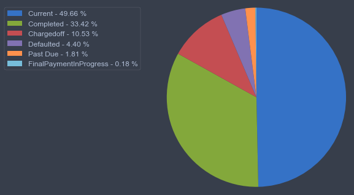

```python
# Using Pie chart to visualize status Loan
x = np.char.array(['Current', 'Completed', 'Chargedoff', 'Defaulted', 'Past Due', 'FinalPaymentInProgress'])
y = np.array([56576, 38074, 11992, 5018, 2067, 205])
per = 100.*y/y.sum()
patch, text = plt.pie(y, startangle=90, radius=1.2, counterclock = False)
labels = ['{0} - {1:1.2f} %'.format(i,j) for i,j in zip(x, per)]
sort_legend = True
if sort_legend:
    patch, labels, dummy =  zip(*sorted(zip(patch, labels, y), key=lambda x: x[2], reverse=True))

plt.legend(patch, labels, loc='left center', bbox_to_anchor=(-0.1, 1.), fontsize=12)
#plt.savefig('piechart.png', bbox_inches='tight')
```

### IsBorrowerHomeowner

```python
selected_df['IsBorrowerHomeowner'].value_counts()
```

```
True     57406
False    56027
Name: IsBorrowerHomeowner, dtype: int64
```

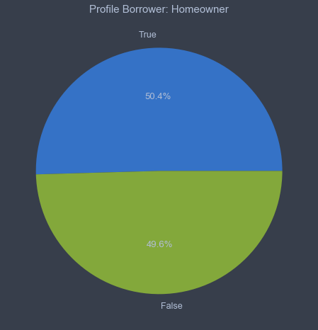

```python
# Using Pie chart to visualize IsBorrowerHomeowner
plt.pie([57478, 56459], explode = (0, 0), labels = ['True', 'False'], autopct='%1.1f%%')

plt.title('Profile Borrower: Homeowner', fontsize=15)
plt.gcf().set_size_inches(8, 8)
plt.show()
```

**Observation:**  
As the graph show 50.4% of borrower are classified as a homeowner, while the 49.6% not.

### IncomeVerifiable

```python
selected_df['IncomeVerifiable'].value_counts()
```

```
True     104770
False      8663
Name: IncomeVerifiable, dtype: int64
```

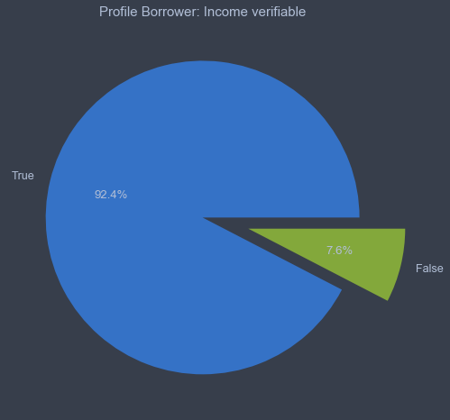

```python
# Using Pie chart to visualize IncomeVerifiable
plt.pie([105268, 8669], explode = (0, .3), labels = ['True', 'False'], autopct='%1.1f%%')
plt.title('Profile Borrower: Income verifiable', fontsize=15)
plt.gcf().set_size_inches(8, 8)
plt.show()
```

### ListingCategory

```python
# Using bar chart to visualize ListingCategory
list_cat = selected_df['ListingCategory'].value_counts()
list_per = selected_df['ListingCategory'].value_counts(normalize=True) * 100

lists = pd.concat([list_cat, list_per], axis=1).set_axis(['listing category', 'percentage'], axis=1, inplace=False)

print(lists)
```

```
                    listing category  percentage
Debt Consolidation             58303   51.398623
Not Available                  16468   14.517821
Other                          10493    9.250395
Home Improvement                7433    6.552767
Business                        7188    6.336780
Auto                            2572    2.267418
Personal Loan                   2395    2.111379
Household Expenses              1996    1.759629
Medical/Dental                  1522    1.341761
Taxes                            885    0.780196
Large Purchases                  876    0.772262
Wedding Loans                    771    0.679696
Vacation                         768    0.677052
Student Use                      756    0.666473
Motorcycle                       304    0.268000
Engagement Ring                  217    0.191302
Baby&Adoption                    199    0.175434
Cosmetic Procedure                91    0.080224
Boat                              85    0.074934
Green Loans                       59    0.052013
RV                                52    0.045842
```

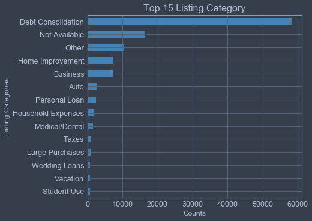

```python
# We can reduce Listing category attributes In the  visualization such as Motorcycle, Engagement Ring,
# Baby&Adoption, Cosmetic Procedure, Boat, Green Loans, and RV
# as the percentage for them is really small (between 0.2% and 0.04%).
list_cat = selected_df['ListingCategory'].value_counts()[0:14].sort_values(axis=0, ascending=True)
list_cat.plot(kind = 'barh', color=['steelblue'])
plt.title('Top 15 Listing Category', size=16)
plt.xlabel('Counts', size=12)
plt.ylabel('Listing Categories', size=12)
#plt.savefig('top-listing-category.png');
```

### Employment Status

```python
employmentStatus = selected_df['EmploymentStatus'].value_counts()
employmentStatus_per = selected_df['EmploymentStatus'].value_counts(normalize=True) * 100

employmentStatus_overall = pd.concat([employmentStatus, employmentStatus_per], axis=1).set_axis(['Customer status', 'percentage'], axis=1, inplace=False)

print(employmentStatus_overall)
```

```
               Customer status  percentage
Employed                 67318   59.346046
Full-time                26353   23.232216
Not available             7106    6.264491
Self-employed             6132    5.405834
Other                     3806    3.355285
Part-time                 1088    0.959157
Not employed               835    0.736117
Retired                    795    0.700854
```

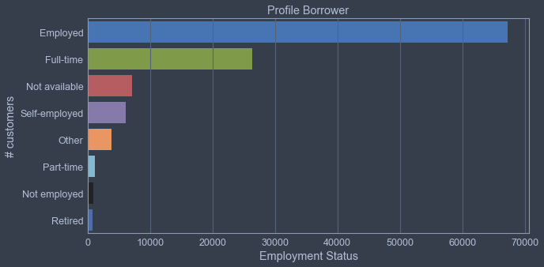

```python
# Visualization of the employment status:

order = selected_df['EmploymentStatus'].value_counts().index
plt.figure(figsize=[10, 5])
sns.countplot(data = selected_df, y = 'EmploymentStatus', order=order)
plt.title('Profile Borrower')
plt.xlabel('Employment Status')
plt.ylabel('# customers');
```

### ProsperScore

```python
# As described before, The score ranges from 1-10, with 10 being the best,
# or lowest risk score. Applicable for loans originated after July 2009.
prosperScore = selected_df['ProsperScore'].value_counts()
prosperScore_per = selected_df['ProsperScore'].value_counts(normalize=True) *100
prosperScore_overall = pd.concat([prosperScore, prosperScore_per], axis = 1).set_axis(['score', 'percentage'], axis = 1, inplace=False)
print(prosperScore_overall)
```

```
      score  percentage
4.0   12594   14.843188
6.0   12278   14.470753
8.0   12053   14.205570
7.0   10597   12.489540
5.0    9811   11.563167
3.0    7641    9.005622
9.0    6910    8.144071
2.0    5765    6.794583
10.0   4750    5.598312
11.0   1456    1.716030
1.0     992    1.169163
```

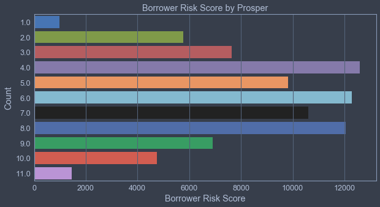

```python
plt.figure(figsize=[10, 5])
#binsize=1
#bins = np.arange(0, selected_df['ProsperScore'].max()+binsize, binsize)
sns.countplot(data=selected_df, y='ProsperScore')
plt.title('Borrower Risk Score by Prosper')
plt.xlabel('Borrower Risk Score')
plt.ylabel('Count');
```

### CurrentCreditLines

```python
selected_df['CurrentCreditLines'].describe()
```

```
count    106325.000000
mean         10.317479
std           5.457921
min           0.000000
25%           7.000000
50%          10.000000
75%          13.000000
max          59.000000
Name: CurrentCreditLines, dtype: float64
```

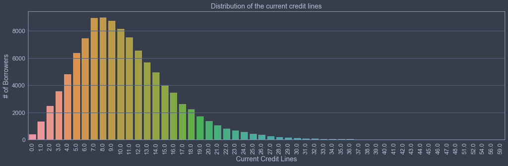

```python
plt.subplots(figsize = [18,5])
sns.countplot(data = selected_df, x = 'CurrentCreditLines')
plt.xlabel('Current Credit Lines')
plt.ylabel('# of Borrowers')
plt.title('Distribution of the current credit lines')
plt.xticks(rotation=90);
```

### The origination amount of loan

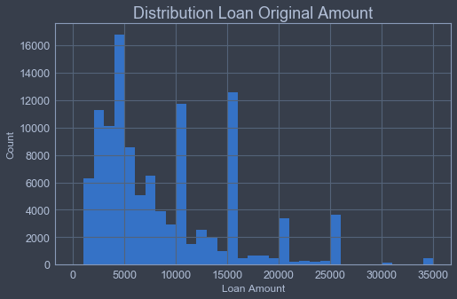

```python
binsize = 1000
bins = np.arange(0, selected_df['LoanOriginalAmount'].max()+binsize, binsize)

plt.figure(figsize=[8, 5])
plt.hist(data = selected_df, x = 'LoanOriginalAmount', bins = bins)
plt.xlabel('Loan Amount', size=12)
plt.ylabel('Count', size=12)
plt.title('Distribution Loan Original Amount', size=18)
```

**Observation:**  
There are many peaks around 10k, 15k, 20k, 25k and 35k.

### OpenRevolvingAccounts

```python
selected_df['OpenRevolvingAccounts'].describe()
```

```
count    113433.000000
mean          6.992295
std           4.626109
min           0.000000
25%           4.000000
50%           6.000000
75%           9.000000
max          51.000000
Name: OpenRevolvingAccounts, dtype: float64
```

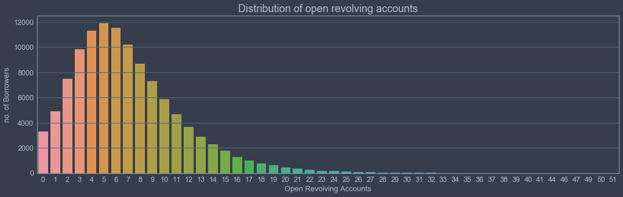

```python
plt.figure(figsize=[18, 5])

sns.countplot(data = selected_df, x = 'OpenRevolvingAccounts')
plt.title('Distribution of open revolving accounts', size = 18)
plt.xlabel('Open Revolving Accounts', size = 13)
plt.ylabel('no. of Borrowers', size = 13);
```

### DebtToIncomeRatio

```python
selected_df['DebtToIncomeRatio'].describe()
```

```
count    104908.000000
mean          0.276733
std           0.552856
min           0.000000
25%           0.140000
50%           0.220000
75%           0.320000
max          10.010000
Name: DebtToIncomeRatio, dtype: float64
```

```
(0, 1.5)
```

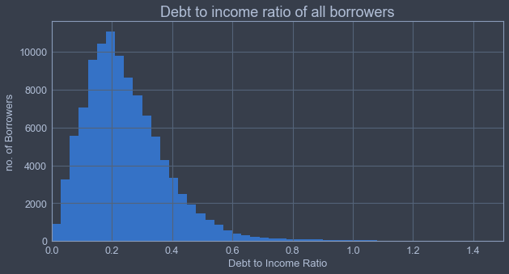

```python
binsize = 0.03
bins = np.arange(0, selected_df['DebtToIncomeRatio'].max()+binsize, binsize)

plt.figure(figsize=[10, 5])
plt.hist(data = selected_df, x = 'DebtToIncomeRatio', bins = bins)
plt.title('Debt to income ratio of all borrowers', size = 18)
plt.xlabel('Debt to Income Ratio', size = 13)
plt.ylabel('no. of Borrowers', size = 13);
plt.xlim(0,1.5)
```

### Of the features you investigated, were there any unusual distributions? Did you perform any operations on the data to tidy, adjust, or change the form of the data? If so, why did you do this?

I decided to join all 'Past Due' variables under an unique status, as I observed that there are a small contribute for the loan status Past Due compared to all loan status amounts. Also, the cancelled status has been ignored (0.004%). In the Listing category I dropped Motorcycle, Engagement Ring, Baby&Adoption, Cosmetic Procedure, Boat, Green Loans, and RV as their percentage was small (between 0.2% and 0.04%).

# Bivariate Exploration

**In this section, I investigate relationships between pairs of variables in the data.**

### Loan Status VS Current Credit Lines

```python
selected_df[['LoanStatus', 'CurrentCreditLines']].groupby('LoanStatus').describe()
```

| LoanStatus | CurrentCreditLines count | CurrentCreditLines mean | CurrentCreditLines std | CurrentCreditLines min | CurrentCreditLines 25% | CurrentCreditLines 50% | CurrentCreditLines 75% | CurrentCreditLines max |
| --- | --- | --- | --- | --- | --- | --- | --- | --- |
| Defaulted | 3291.0 | 10.644485 | 5.990622 | 0.0 | 6.0 | 10.0 | 14.0 | 52.0 |
| Chargedoff | 10636.0 | 8.845807 | 5.744220 | 0.0 | 5.0 | 8.0 | 12.0 | 48.0 |
| Past Due | 2067.0 | 9.858249 | 5.351510 | 0.0 | 6.0 | 9.0 | 13.0 | 36.0 |
| Current | 56570.0 | 10.962878 | 5.272037 | 0.0 | 7.0 | 10.0 | 14.0 | 54.0 |
| FinalPaymentInProgress | 205.0 | 10.243902 | 5.281212 | 2.0 | 7.0 | 9.0 | 13.0 | 31.0 |
| Completed | 33555.0 | 9.692594 | 5.460938 | 0.0 | 6.0 | 9.0 | 13.0 | 59.0 |

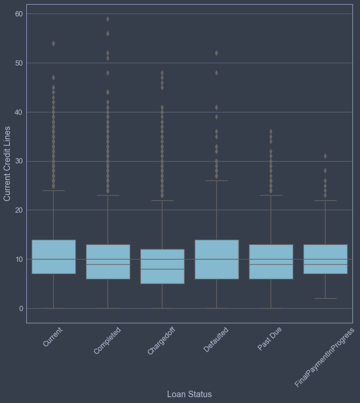

```python
# loanStatus's order
order = selected_df['LoanStatus'].value_counts().index

# Define figure size
plt.figure(figsize = [10, 10])

color = sns.color_palette()[5]
sns.boxplot(data=selected_df, x='LoanStatus', y='CurrentCreditLines', color = color, order=order)
plt.xlabel('Loan Status')
plt.ylabel('Current Credit Lines')
plt.xticks(rotation=45);
```

**Observation:**  
There is not a considerable difference between the portion of the credit lines for each loan status.

### Loan Status VS Open Resolving Accounts

```python
selected_df[['LoanStatus', 'OpenRevolvingAccounts']].groupby('LoanStatus').describe()
```

| LoanStatus | OpenRevolvingAccounts count | OpenRevolvingAccounts mean | OpenRevolvingAccounts std | OpenRevolvingAccounts min | OpenRevolvingAccounts 25% | OpenRevolvingAccounts 50% | OpenRevolvingAccounts 75% | OpenRevolvingAccounts max |
| --- | --- | --- | --- | --- | --- | --- | --- | --- |
| Defaulted | 4887.0 | 5.779415 | 4.922739 | 0.0 | 2.0 | 5.0 | 8.0 | 51.0 |
| Chargedoff | 11919.0 | 5.602903 | 4.550213 | 0.0 | 2.0 | 5.0 | 8.0 | 41.0 |
| Past Due | 2067.0 | 6.632801 | 4.315728 | 0.0 | 3.0 | 6.0 | 9.0 | 34.0 |
| Current | 56570.0 | 7.849549 | 4.573137 | 0.0 | 5.0 | 7.0 | 10.0 | 50.0 |
| FinalPaymentInProgress | 205.0 | 7.297561 | 4.440703 | 0.0 | 4.0 | 6.0 | 9.0 | 24.0 |
| Completed | 37780.0 | 6.322710 | 4.448539 | 0.0 | 3.0 | 5.0 | 8.0 | 49.0 |

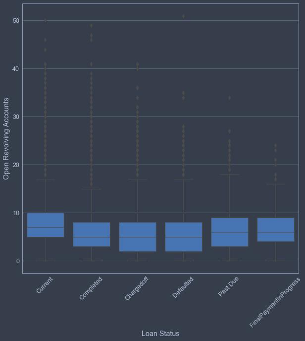

```python
plt.figure(figsize = [10, 10])
color = sns.color_palette()[0]
sns.boxplot(data=selected_df, x='LoanStatus', y='OpenRevolvingAccounts', color = color, order=order)
plt.xlabel('Loan Status')
plt.ylabel('Open Revolving Accounts')
plt.xticks(rotation=45);
```

### Loan Status VS Prosper Score

```python
selected_df[['LoanStatus', 'ProsperScore']].groupby('LoanStatus').describe()
```

| LoanStatus | ProsperScore count | ProsperScore mean | ProsperScore std | ProsperScore min | ProsperScore 25% | ProsperScore 50% | ProsperScore 75% | ProsperScore max |
| --- | --- | --- | --- | --- | --- | --- | --- | --- |
| Defaulted | 1005.0 | 5.619900 | 2.207106 | 1.0 | 4.0 | 6.0 | 7.0 | 11.0 |
| Chargedoff | 5336.0 | 5.390742 | 2.152321 | 1.0 | 4.0 | 5.0 | 7.0 | 10.0 |
| Past Due | 2067.0 | 5.063861 | 2.150167 | 1.0 | 3.0 | 5.0 | 7.0 | 11.0 |
| Current | 56570.0 | 5.838077 | 2.391438 | 1.0 | 4.0 | 6.0 | 8.0 | 11.0 |
| FinalPaymentInProgress | 205.0 | 5.751220 | 2.487530 | 1.0 | 4.0 | 6.0 | 8.0 | 11.0 |
| Completed | 19664.0 | 6.536513 | 2.303850 | 1.0 | 5.0 | 7.0 | 8.0 | 11.0 |

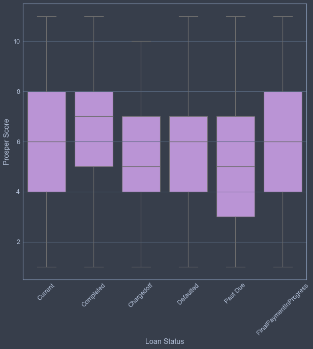

```python
plt.figure(figsize = [10, 10])
color = sns.color_palette()[10]
sns.boxplot(data=selected_df, x='LoanStatus', y='ProsperScore', color = color, order=order)
plt.xlabel('Loan Status')
plt.ylabel('Prosper Score')
plt.xticks(rotation=45);
```

**Observation:**  
The graph shows that clients with higher prosper scores approximate to a loan status completed. Regardless, loans charged-off have a lower prosper risk score.

### Loan Status VS Debt to Income Ratio

```python
selected_df[['LoanStatus', 'DebtToIncomeRatio']].groupby('LoanStatus').describe()
```

| LoanStatus | DebtToIncomeRatio count | DebtToIncomeRatio mean | DebtToIncomeRatio std | DebtToIncomeRatio min | DebtToIncomeRatio 25% | DebtToIncomeRatio 50% | DebtToIncomeRatio 75% | DebtToIncomeRatio max |
| --- | --- | --- | --- | --- | --- | --- | --- | --- |
| Defaulted | 4640.0 | 0.376559 | 0.996079 | 0.00 | 0.140000 | 0.23 | 0.354997 | 10.01 |
| Chargedoff | 10686.0 | 0.340793 | 0.914056 | 0.00 | 0.135437 | 0.21 | 0.330000 | 10.01 |
| Past Due | 1857.0 | 0.293430 | 0.478572 | 0.01 | 0.160000 | 0.23 | 0.350000 | 10.01 |
| Current | 52474.0 | 0.262026 | 0.277184 | 0.00 | 0.160000 | 0.23 | 0.320000 | 10.01 |
| FinalPaymentInProgress | 189.0 | 0.227090 | 0.111806 | 0.02 | 0.150000 | 0.20 | 0.300000 | 0.57 |
| Completed | 35057.0 | 0.265406 | 0.631245 | 0.00 | 0.120000 | 0.19 | 0.290000 | 10.01 |

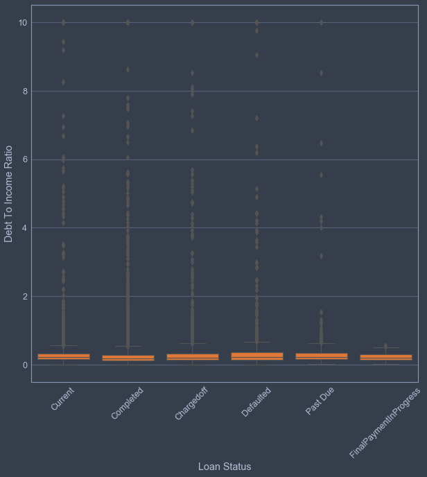

```python
plt.figure(figsize = [10, 10])
color = sns.color_palette()[11]
sns.boxplot(data=selected_df, x='LoanStatus', y='DebtToIncomeRatio', color = color, order=order)
plt.xlabel('Loan Status')
plt.ylabel('Debt To Income Ratio')
plt.xticks(rotation=45);
```

**Observation:**  
The completed and FinalPaymentinProgress loan status the lower Debt to income ratio.

### Loan Status VS Loan Original

```python
selected_df[['LoanStatus', 'LoanOriginalAmount']].groupby('LoanStatus').describe()
```

| LoanStatus | LoanOriginalAmount count | LoanOriginalAmount mean | LoanOriginalAmount std | LoanOriginalAmount min | LoanOriginalAmount 25% | LoanOriginalAmount 50% | LoanOriginalAmount 75% | LoanOriginalAmount max |
| --- | --- | --- | --- | --- | --- | --- | --- | --- |
| Defaulted | 4887.0 | 6597.319214 | 5871.038780 | 1000.0 | 2600.0 | 4500.0 | 8000.0 | 25000.0 |
| Chargedoff | 11919.0 | 6423.014431 | 5342.092718 | 1000.0 | 3000.0 | 4500.0 | 8000.0 | 25000.0 |
| Past Due | 2067.0 | 8258.437349 | 5557.533710 | 1500.0 | 4000.0 | 6500.0 | 11000.0 | 35000.0 |
| Current | 56570.0 | 10361.014707 | 6519.183911 | 2000.0 | 4000.0 | 10000.0 | 15000.0 | 35000.0 |
| FinalPaymentInProgress | 205.0 | 8346.121951 | 6144.829289 | 2000.0 | 4000.0 | 6500.0 | 10000.0 | 31000.0 |
| Completed | 37780.0 | 6213.780651 | 5095.209308 | 1000.0 | 2600.0 | 4500.0 | 8000.0 | 35000.0 |

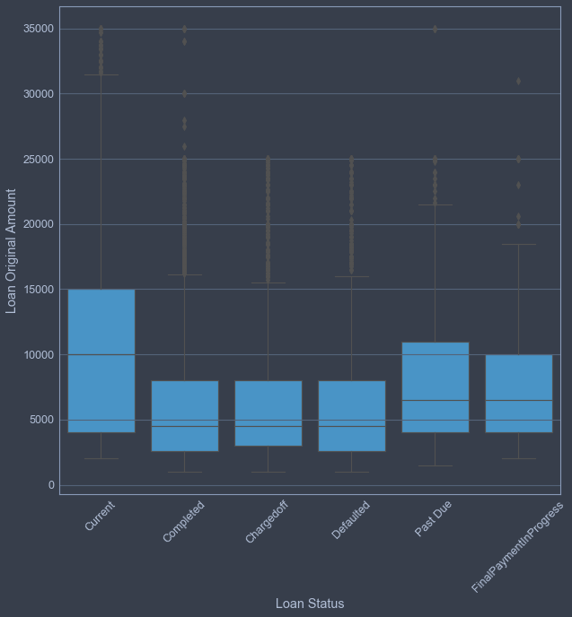

```python
plt.figure(figsize = [10, 10])
color = sns.color_palette()[12]
sns.boxplot(data=selected_df, x='LoanStatus', y='LoanOriginalAmount', color = color, order=order)
plt.xlabel('Loan Status')
plt.ylabel('Loan Original Amount')
plt.xticks(rotation=45);
```

### Loan Status VS Listing Category

```python
selected_df[['LoanStatus', 'ListingCategory']].groupby('LoanStatus').describe()
```

| LoanStatus | ListingCategory count | ListingCategory unique | ListingCategory top | ListingCategory freq |
| --- | --- | --- | --- | --- |
| Defaulted | 4887 | 18 | Not Available | 2772 |
| Chargedoff | 11919 | 20 | Not Available | 3719 |
| Past Due | 2067 | 19 | Debt Consolidation | 1131 |
| Current | 56570 | 19 | Debt Consolidation | 39189 |
| FinalPaymentInProgress | 205 | 14 | Debt Consolidation | 115 |
| Completed | 37780 | 21 | Debt Consolidation | 13167 |

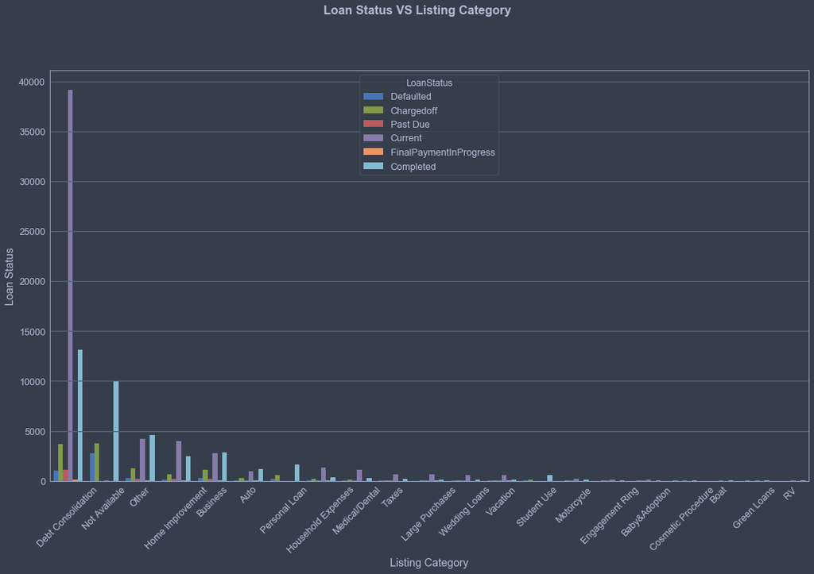

```python
# plot chart
plt.figure(figsize = [18, 10])
graph = sns.countplot(data = selected_df, x = 'ListingCategory', hue = 'LoanStatus', order = selected_df.ListingCategory.value_counts().index);
graph.set_xlabel('Listing Category');
graph.set_ylabel('Loan Status');
plt.xticks(rotation=45);
plt.suptitle('Loan Status VS Listing Category', y=1.0, fontsize=16, fontweight='bold');
```

**Observation:**  
We can observe that Defaulted and charged off the most popular listing category is not available. While, the loan status Past Due, Current, FinalPaymentInProgress, and Completed, the most popular listing category is Debt Consolidation.

### Loan Status VS IsBorrowerHomeOwner

```python
selected_df[['LoanStatus', 'IsBorrowerHomeowner']].groupby('LoanStatus').describe()
```

| LoanStatus | IsBorrowerHomeowner count | IsBorrowerHomeowner unique | IsBorrowerHomeowner top | IsBorrowerHomeowner freq |
| --- | --- | --- | --- | --- |
| Defaulted | 4887 | 2 | False | 2616 |
| Chargedoff | 11919 | 2 | False | 6594 |
| Past Due | 2067 | 2 | False | 1064 |
| Current | 56570 | 2 | True | 30477 |
| FinalPaymentInProgress | 205 | 2 | True | 110 |
| Completed | 37780 | 2 | False | 19562 |

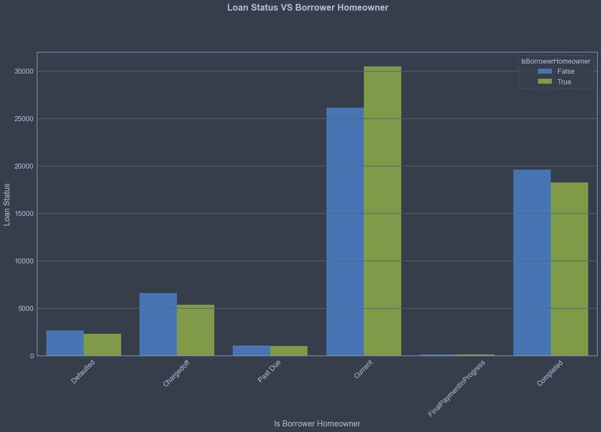

```python
plt.figure(figsize = [18, 10])
graph = sns.countplot(data = selected_df, x = 'LoanStatus', hue = 'IsBorrowerHomeowner');
graph.set_xlabel('Is Borrower Homeowner');
graph.set_ylabel('Loan Status');
plt.xticks(rotation=45);
plt.suptitle('Loan Status VS Borrower Homeowner', y=1.0, fontsize=16, fontweight='bold');
```

### Loan Status VS Employment status

```python
selected_df[['LoanStatus', 'EmploymentStatus']].groupby('LoanStatus').describe()
```

| LoanStatus | EmploymentStatus count | EmploymentStatus unique | EmploymentStatus top | EmploymentStatus freq |
| --- | --- | --- | --- | --- |
| Defaulted | 4887 | 8 | Full-time | 2217 |
| Chargedoff | 11919 | 8 | Full-time | 5343 |
| Past Due | 2067 | 7 | Employed | 1725 |
| Current | 56570 | 7 | Employed | 48925 |
| FinalPaymentInProgress | 205 | 4 | Employed | 177 |
| Completed | 37780 | 8 | Full-time | 17395 |

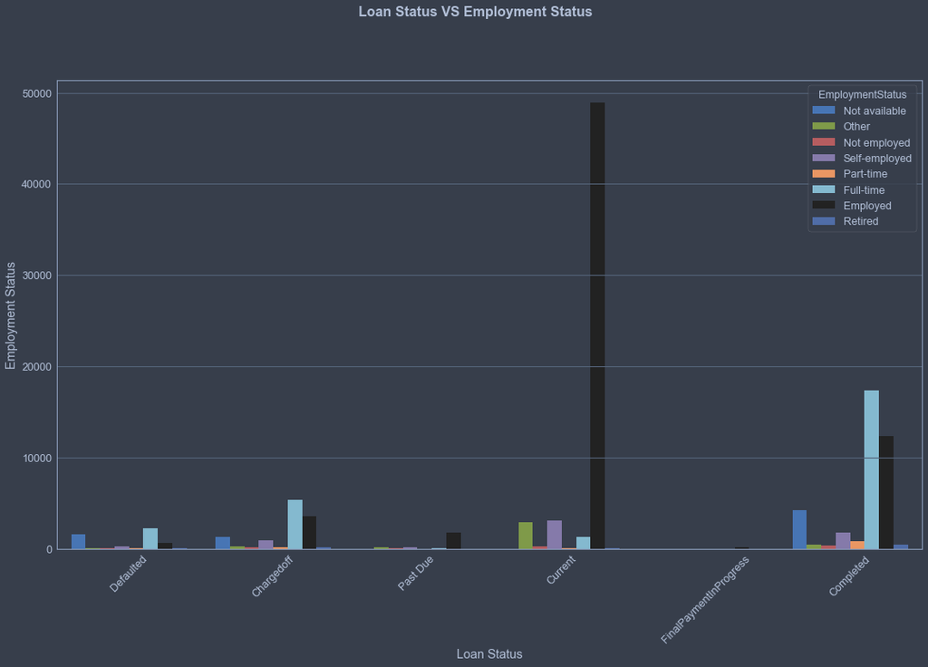

```python
plt.figure(figsize = [18, 10])
graph = sns.countplot(data = selected_df, x = 'LoanStatus', hue = 'EmploymentStatus');
graph.set_xlabel('Loan Status');
graph.set_ylabel('Employment Status');
plt.xticks(rotation=45);
plt.suptitle('Loan Status VS Employment Status', y=1.0, fontsize=16, fontweight='bold');
```

**Observation:**  
For defaulter, charged off and completed the most popular employment status is full-time. The loan status Past Due, Current, and FinalPaymentInProgress the most popular employment status is employed,

### Loan Status VS Income Verifiable

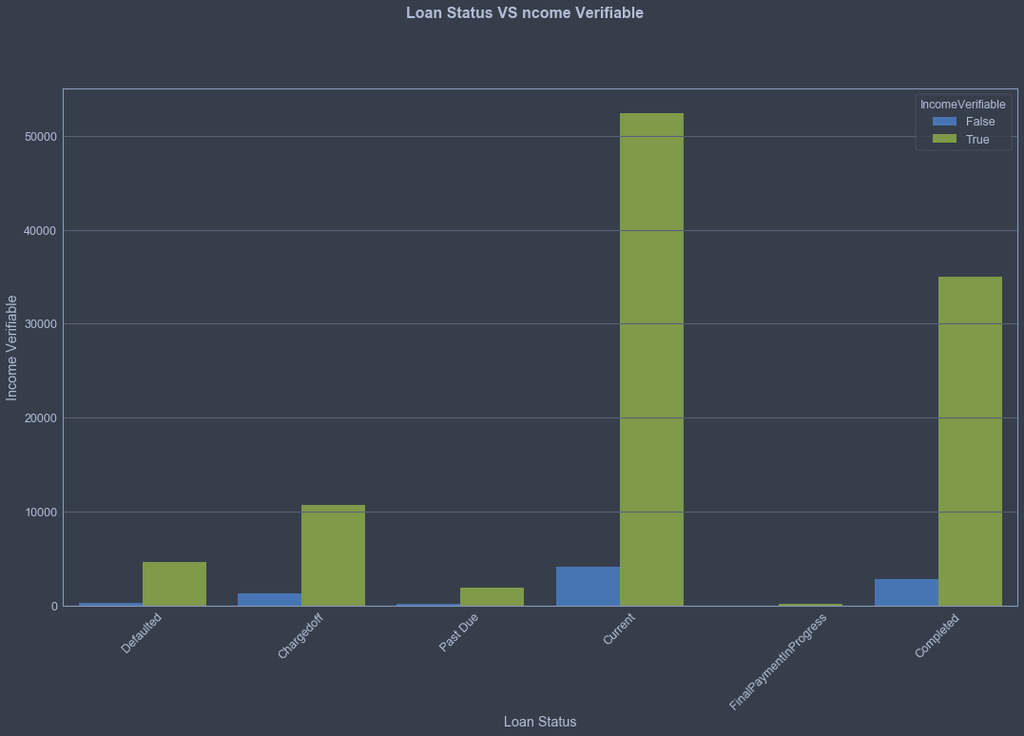

```python
plt.figure(figsize = [18, 10])
graph = sns.countplot(data = selected_df, x = 'LoanStatus', hue = 'IncomeVerifiable');
graph.set_xlabel('Loan Status');
graph.set_ylabel('Income Verifiable');
plt.xticks(rotation=45);
plt.suptitle('Loan Status VS ncome Verifiable', y=1.0, fontsize=16, fontweight='bold');
```

**We can end the bivariate exploration with the correlation for numeric variables.**

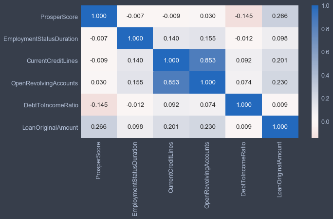

```python
# Correlation plot
numeric = ['ProsperScore', 'EmploymentStatusDuration', 'CurrentCreditLines', 'OpenRevolvingAccounts',
               'DebtToIncomeRatio', 'LoanOriginalAmount']
plt.figure(figsize = [10, 5])
sns.heatmap(selected_df[numeric].corr(), annot = True, fmt = '.3f', cmap = 'vlag_r', center = 0)
plt.show()
```

### Did you observe any interesting relationships between the other features (not the main feature(s) of interest)?

In the numeric features, according to the correlation coefficient, there is a positive relationship between proper score, the borrower risk attributed, and the original loan amount.

# Multivariate Exploration

##### I created plots of three or more attributes to investigate the loan data even further.

```python
selected_df[['LoanStatus', 'EmploymentStatus', 'EmploymentStatusDuration']].groupby('EmploymentStatus').describe()
```

| EmploymentStatus | EmploymentStatusDuration count | EmploymentStatusDuration mean | EmploymentStatusDuration std | EmploymentStatusDuration min | EmploymentStatusDuration 25% | EmploymentStatusDuration 50% | EmploymentStatusDuration 75% | EmploymentStatusDuration max |
| --- | --- | --- | --- | --- | --- | --- | --- | --- |
| Not available | 0.0 | NaN | NaN | NaN | NaN | NaN | NaN | NaN |
| Other | 3800.0 | 102.201316 | 134.944900 | 0.0 | 8.0 | 52.0 | 132.0 | 755.0 |
| Not employed | 834.0 | 36.083933 | 56.229744 | 0.0 | 3.0 | 13.0 | 41.0 | 359.0 |
| Self-employed | 6130.0 | 98.806525 | 99.612436 | 0.0 | 26.0 | 68.0 | 138.0 | 649.0 |
| Part-time | 1088.0 | 37.370404 | 46.545402 | 0.0 | 8.0 | 22.0 | 50.0 | 552.0 |
| Full-time | 26340.0 | 79.834814 | 83.625702 | 0.0 | 20.0 | 51.0 | 110.0 | 623.0 |
| Employed | 67317.0 | 103.478022 | 94.933951 | 0.0 | 31.0 | 75.0 | 150.0 | 745.0 |
| Retired | 795.0 | 100.400000 | 83.264221 | 0.0 | 42.0 | 81.0 | 135.5 | 584.0 |

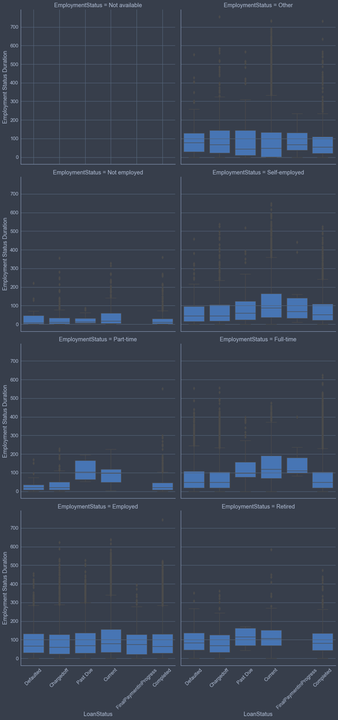

```python
employment_s = selected_df[selected_df['EmploymentStatus'] != 'Not available'][['LoanStatus', 'EmploymentStatus', 'EmploymentStatusDuration']]
graph = sns.FacetGrid(data = employment_s, col = 'EmploymentStatus', col_wrap = 2, size = 6, dropna=True, legend_out=True)
graph.map(sns.boxplot,'LoanStatus', 'EmploymentStatusDuration')
graph.set_xlabels()
graph.set_ylabels('Employment Status Duration')
graph.set_xticklabels(rotation=45)
```

### Talk about some of the relationships you observed in this part of the investigation. Were there features that strengthened each other in terms of looking at your feature(s) of interest?

I expected to understand better what factors affect a loan's charged-off and defaulted status. I couldn't observe them during the analysis.

### Were there any interesting or surprising interactions between features?

I desired to understand better what aspects affect a loan's charged-off and defaulted status. I couldn't observe them during the analysis.

### Were there any interesting or surprising interactions between features?

I believed a higher contribution from "non-employed status" customer and debt to income ratio, on charged-off and defaulted loans. But I couldn't observe them during the analysis.